# Prediction Assignment

Nazrul

19 Februari 2017

## Background

Using devices such as Jawbone Up, Nike FuelBand, and Fitbit it is now possible to collect a large amount of data about personal activity relatively inexpensively. These type of devices are part of the quantified self movement - a group of enthusiasts who take measurements about themselves regularly to improve their health, to find patterns in their behavior, or because they are tech geeks.

One thing that people regularly do is quantify how much of a particular activity they do, but they rarely quantify how well they do it. In this project, the goal will be to use data from accelerometers on the belt, forearm, arm, and dumbell of 6 participants. They were asked to perform barbell lifts correctly and incorrectly in 5 different ways. More information is available from the website here: http://groupware.les.inf.puc-rio.br/har (see the section on the Weight Lifting Exercise Dataset).

The goal of this project is to predict the manner in which they did the exercise. This is the “classe” variable in the training set.

```r
library(caret)
library(rpart)
```

```r
library(rpart.plot)
library(RColorBrewer)
library(rattle)
library(randomForest)
library(knitr)
```

## Getting and loading the data

Download and load the data.

```r
#download.file("https://d396qusza40orc.cloudfront.net/predmachlearn/pml-training.csv", destfile = "./pml-training.csv")
#download.file("https://d396qusza40orc.cloudfront.net/predmachlearn/pml-testing.csv", destfile = "./pml-testing.csv")

training = read.csv("pml-training.csv", na.strings=c("", "NA", "NULL", "#DIV/0!"))
testing = read.csv("pml-testing.csv", na.strings=c("", "NA", "NULL", "#DIV/0!"))

dim(training)
```

```
## [1] 19622   160
```

```r
dim(testing)
```

```
## [1]  20 160
```

Partioning the training set into two

```r
inTrain <- createDataPartition(training$classe, p=0.6, list=FALSE)
myTraining <- training[inTrain, ]
myTesting <- training[-inTrain, ]
dim(myTraining); dim(myTesting)
```

```
## [1] 11776   160
```

```
## [1] 7846  160
```

## Cleaning the data

Remove NearZeroVariance variables

```r
nzv <- nearZeroVar(myTraining, saveMetrics=TRUE)
myTraining <- myTraining[,nzv$nzv==FALSE]

nzv<- nearZeroVar(myTesting,saveMetrics=TRUE)
myTesting <- myTesting[,nzv$nzv==FALSE]
```

Remove the first column of the myTraining data set

```r
myTraining <- myTraining[c(-1)]
```

```r
trainingV3 <- myTraining
for(i in 1:length(myTraining)) {
    if( sum( is.na( myTraining[, i] ) ) /nrow(myTraining) >= .7) {
        for(j in 1:length(trainingV3)) {
            if( length( grep(names(myTraining[i]), names(trainingV3)[j]) ) == 1)  {
                trainingV3 <- trainingV3[ , -j]
            }
        }
    }
}

# Set back to the original variable name
myTraining <- trainingV3
rm(trainingV3)
```

Transform the myTesting and testing data sets

```r
clean1 <- colnames(myTraining)
clean2 <- colnames(myTraining[, -58])  # remove the classe column
myTesting <- myTesting[clean1]         # allow only variables in myTesting that are also in myTraining
testing <- testing[clean2]             # allow only variables in testing that are also in myTraining

dim(myTesting)
```

```
## [1] 7846   58
```

```r
dim(testing)
```

```
## [1] 20 57
```

Coerce the data into the same type

```r
for (i in 1:length(testing) ) {
    for(j in 1:length(myTraining)) {
        if( length( grep(names(myTraining[i]), names(testing)[j]) ) == 1)  {
            class(testing[j]) <- class(myTraining[i])
        }
    }
}

# To get the same class between testing and myTraining
testing <- rbind(myTraining[2, -58] , testing)
testing <- testing[-1,]
```

## Prediction with Decision Trees

[figure not shown]

```r
set.seed(12345)
modFitA1 <- rpart(classe ~ ., data=myTraining, method="class")
fancyRpartPlot(modFitA1)
```

```r
predictionsA1 <- predict(modFitA1, myTesting, type = "class")
cmtree = with(myTesting,table(predictionsA1,myTesting$classe))
#cmtree <- confusionMatrix(predictionsA1, myTesting$classe)
cmtree
```

```
##
## predictionsA1    A    B    C    D    E
##             A 2160   69    8    1    0
##             B   67 1355  117    7    0
##             C    5   81 1213  101    2
##             D    0   13   21  976   84
##             E    0    0    9  201 1356
```

```r
sum(diag(cmtree))/sum(as.vector(cmtree)) # error rate
```

```
## [1] 0.8998216
```

## Prediction with Random Forests

```r
set.seed(12345)
rf.training=randomForest(classe~.,data=myTraining)
rf.training
```

```
##
## Call:
##  randomForest(formula = classe ~ ., data = myTraining)
##                Type of random forest: classification
##                      Number of trees: 500
## No. of variables tried at each split: 7
##
##         OOB estimate of  error rate: 0.21%
## Confusion matrix:
##      A    B    C    D    E  class.error
## A 3347    1    0    0    0 0.0002986858
## B    3 2276    0    0    0 0.0013163668
## C    0    4 2048    2    0 0.0029211295
## D    0    0    9 1918    3 0.0062176166
## E    0    0    0    3 2162 0.0013856813
```

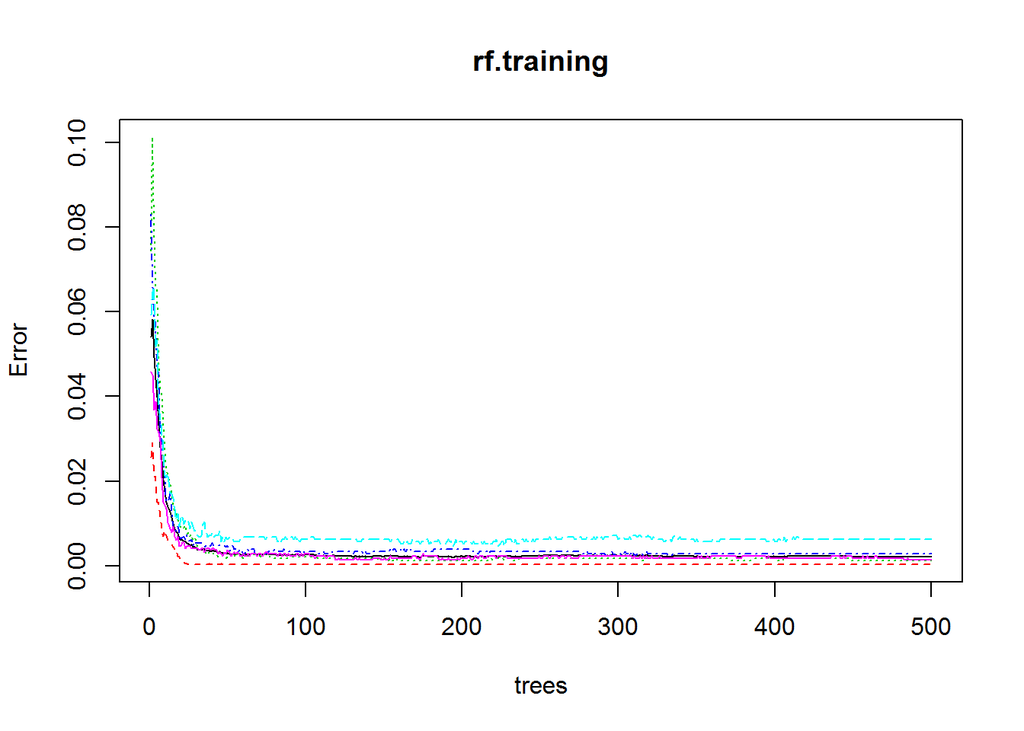

```r
plot(rf.training)
```

## Out-of Sample Accuracy

```r
tree.pred = predict(rf.training,myTesting,type="class")
predMatrix = with(myTesting,table(tree.pred,myTesting$classe))
sum(diag(predMatrix))/sum(as.vector(predMatrix)) # error rate
```

```
## [1] 0.9973235
```

0.99 means we got a very accurate estimate.

No. of variables tried at each split: 7. It means every time we only randomly use 7 predictors to grow the tree.

## Conclusion

Now we can predict the testing data from the website.

```r
predictionB2 <- predict(rf.training, testing, type = "class")
predictionB2
```

[output not shown]